# Polity size and local government performance: evidence from India: Comments

Macartan Humphreys

## So much to like here

- Smart
- Policy relevant
- Rich theoretical questions and nice engagement with mechanisms
- Very clearly done and cleanly written

So much good news!

My comments mostly marginal

## RD

Identification uses fact that:

“villages whose population exceeds one thousand should be allocated into their own GP” 1995/ 2015

## RD

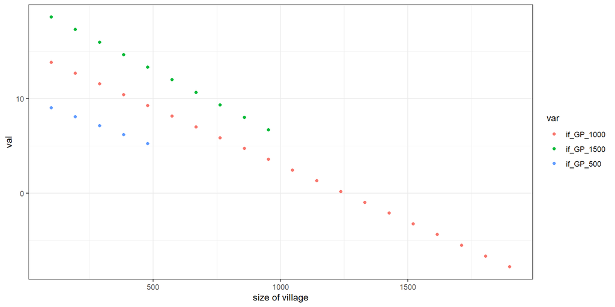

- Note heterogeneity on left (and in principle on right)
- Note some non defined potential outcomes (missing blues)

## Innovation

Two strategies:

For leavers:

$$\mathbb E_x\mathbb E_{i\in A_x}[y_{i}(x) - y_i(1000)]$$
where $A_x$ is the set of villages with population around 1000 in a GP of size $x$.

For remainers

$$\mathbb E_x\mathbb E_{i\in B_x}[y_i(x) - y_i(x-1000)]$$

where $B_x$ is the set of villages with neighbor village around 1000 in a GP of size $x$.

## Comparison

- Strategy 1: is a drop from a given size *to* 1000
- Strategy 2: is a drop from a given size *by* 1000

Note:

- Strategy 1 captures the effects of being in a *new* smaller GP
- Strategy 2 captures the effects of being in an *old*, now smaller, GP

Average effect of dropping by 1000 seems more interpretable than effect of dropping to 1000. More like a derivative!

## Observations

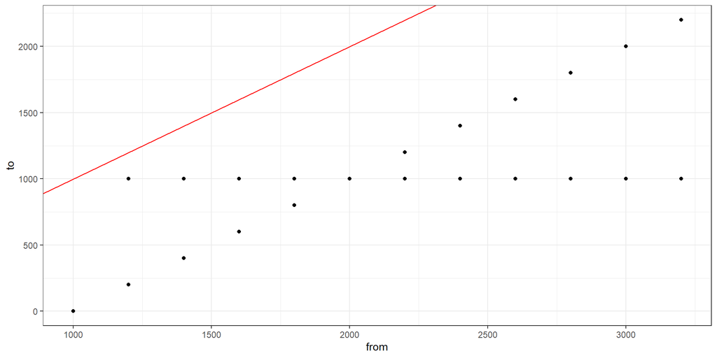

Even with this cleverness:

- Particular set of comparisons.
- Unclear comparability across comparison groups

## To discuss

- How *comparable* are the average numbers between strategy 1 and 2? Quite different estimands.
- How *interpretible* are differences between strata? these are not as-if random

## To discuss

- **Substantive 1**: How much of this could be novelty effects?
- **Substantive 2**: Are there fixed costs per unit? Are smaller units more expensive with very diffuse costs? Interpretation if this is a transfer

## Estimand of most interest?

- Effect of reduction or optimal size?
- Can you predict levels? (Have you considered more structural analysis also?)

## Note on comparing interactions strategy 1 and 2

Clarifying this might help with interpreting interactions:

Interaction inferences: Consider the difference between

- A: 1800 -> (800, 1000) and
- B: 2800 -> (1800, 1000)

For the *splitter* B is a bigger shock than A

For the *remainer* A is a bigger shock than B

## So

Inquiry:

- Can you fill out the potential outcomes schedule?
- Can you get a handle on when small is too small?

And

- Can you challenge the novelty interpretation?

## End

# Small and curmudgeonly

- Did you consider pre-registering
- Rumps could be so small?
- Comment strategy 2: Is taking size of largest the most efficient? Multiple leavers? Predicable population growth: can you use the prediction around 1000.
- Tables and Figures in text please!

## Theories

- Collective action
- Homogeneity of preferences
- Competition

BUt:

- Economies of scale
- Capture
- Externalities
- Small talent pools